# 2.1 K Nearest Neighbors - Project

## Get the Data

```r
library(ISLR)
head(iris)
```

```
##   Sepal.Length Sepal.Width Petal.Length Petal.Width Species
## 1          5.1         3.5          1.4         0.2  setosa
## 2          4.9         3.0          1.4         0.2  setosa
## 3          4.7         3.2          1.3         0.2  setosa
## 4          4.6         3.1          1.5         0.2  setosa
## 5          5.0         3.6          1.4         0.2  setosa
## 6          5.4         3.9          1.7         0.4  setosa
```

## Standardize Data

In this case, the iris data set has all its features in the same order of magnitude, but its good practice (especially with KNN) to standardize features in your data. Lets go ahead and do this even though its not necessary for this data!

Use scale() to standardize the feature columns of the iris dataset. Set this standardized version of the data as a new variable.

```r
stand.features <- scale(iris[1:4])
```

Check that the scaling worked by checking the variance of one of the new columns.

```r
var(stand.features[,1])
```

```
## [1] 1
```

Join the standardized data with the response/target/label column (the column with the species names.

```r
final.data <- cbind(stand.features,iris[5])
```

```r
head(final.data)
```

```
##   Sepal.Length Sepal.Width Petal.Length Petal.Width Species
## 1   -0.8976739  1.01560199    -1.335752   -1.311052  setosa
## 2   -1.1392005 -0.13153881    -1.335752   -1.311052  setosa
## 3   -1.3807271  0.32731751    -1.392399   -1.311052  setosa
## 4   -1.5014904  0.09788935    -1.279104   -1.311052  setosa
## 5   -1.0184372  1.24503015    -1.335752   -1.311052  setosa
## 6   -0.5353840  1.93331463    -1.165809   -1.048667  setosa
```

## Train and Test Splits

Use the caTools library to split your standardized data into train and test sets. Use a 70/30 split.

```r
set.seed(101)

library(caTools)

sample <- sample.split(final.data$Species, SplitRatio = .70)
train <- subset(final.data, sample == TRUE)
test <- subset(final.data, sample == FALSE)
```

## Build a KNN model.

Call the class library.

```r
library(class)
```

Use the knn function to predict Species of the test set. Use k=1

```r
predicted.species <- knn(train[1:4],test[1:4],train$Species,k=1)
predicted.species
```

```
##  [1] setosa     setosa     setosa     setosa     setosa     setosa
##  [7] setosa     setosa     setosa     setosa     setosa     setosa
## [13] setosa     setosa     setosa     versicolor versicolor versicolor
## [19] versicolor versicolor virginica  versicolor versicolor versicolor
## [25] versicolor versicolor virginica  versicolor versicolor versicolor
## [31] virginica  virginica  virginica  virginica  virginica  virginica
## [37] virginica  virginica  virginica  virginica  virginica  virginica
## [43] virginica  virginica  virginica
## Levels: setosa versicolor virginica
```

What was your misclassification rate?

```r
mean(test$Species != predicted.species)
```

```
## [1] 0.04444444
```

## Choosing a K Value

Although our data is quite small for us to really get a feel for choosing a good K value, let’s practice.

Create a plot of the error (misclassification) rate for k values ranging from 1 to 10.

```r
predicted.species <- NULL
error.rate <- NULL

for(i in 1:10){
    set.seed(101)
    predicted.species <- knn(train[1:4],test[1:4],train$Species,k=i)
    error.rate[i] <- mean(test$Species != predicted.species)
}
```

```r
## Plot this out for the elbow method
library(ggplot2)
k.values <- 1:10
error.df <- data.frame(error.rate,k.values)
```

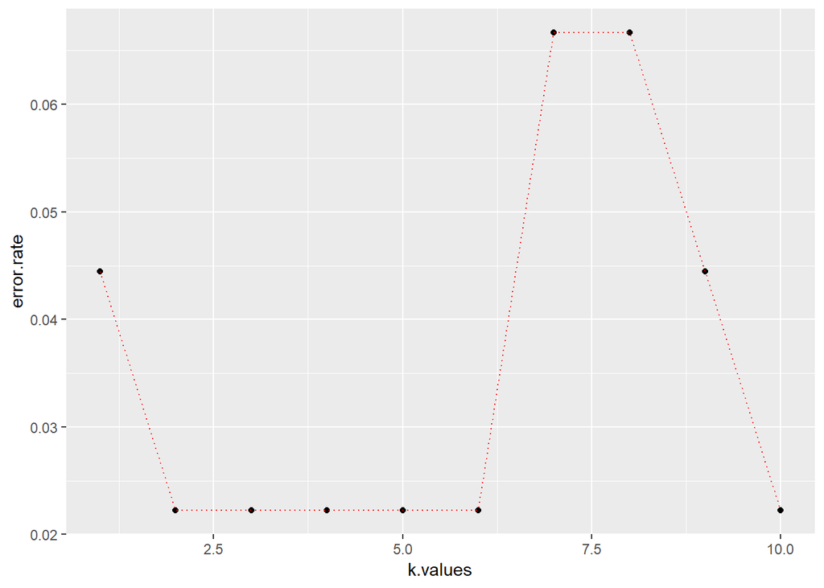

```r
pl <- ggplot(error.df,aes(x=k.values,y=error.rate)) + geom_point()
pl <- pl + geom_line(lty="dotted",color='red')
print(pl)
```